# 1033 Budget Test Case Analysis

ACLU Analytics

3/31/2021

A common argument in support of the 1033 program is that it saves law enforcement agencies (and by extension, taxpayers) money because it prevents them from having to purchase equipment that is instead donated to them for free. If such an effect existed, it would be most evident in law enforcement agencies that receive a large amount of 1033 transfers over a relatively short period of time.

Therefore, to test this hypothesis, we narrow participating law enforcement agencies according to the following criteria: State or local police or sheriff offices that have received more than $800,000 worth of equipment over a period of one year or less, with all transfers shipped 2012 or later. We limit to transfers sent after 2012 because budget information is rarely available before 2011 or so, and to conduct this analysis we need at least one point of budget data *before* the 1033 transfers were made. Narrowing the data in this way yields a list of 31 departments, for 19 of which we were able to find budget information.

The below table summarizes our findings. For each law enforcement agency for which budget information is available, we summarize:

1. The amount of 1033 equipment transferred within a year as a percentage of that year’s total agency budget.
2. The change in agency budget from the year prior to first receipt of 1033 equipment to the year of first receipt of 1033 equipment (Y-1 to Y0).
3. The change in agency budget from the year of first receipt of 1033 equipment to the year following (Y0 to Y1).
4. To accommodate any potential lag in the impact of 1033 equipment on agency budgets, we also include the change from the year following receipt of 1033 equipment to the year after that (Y1 to Y2).

[output not shown]

We also present our findings graphically. The charts below plot year-on-year budgets for each department. A dot is placed above each line graph, representing the additional value provided by 1033 transfers.

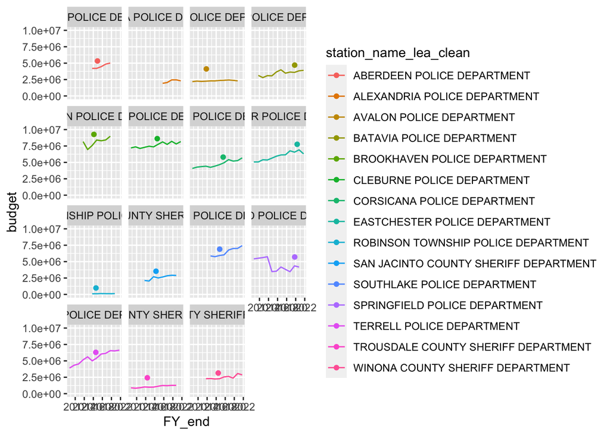

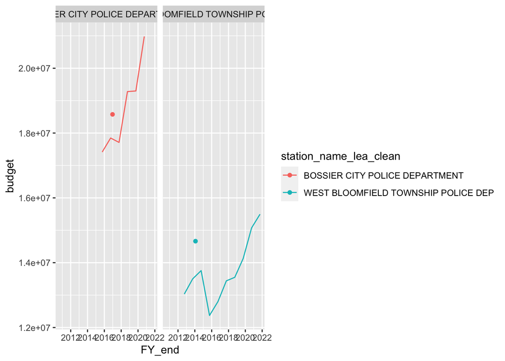

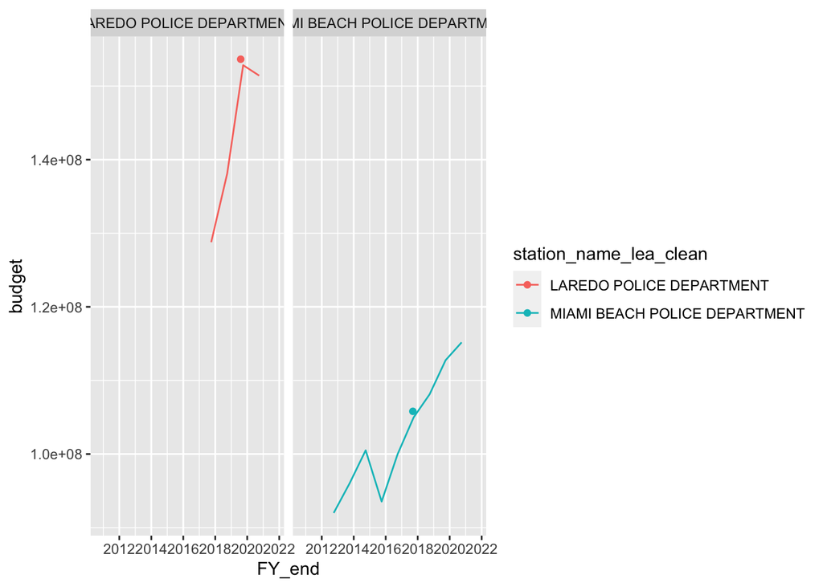